# Codebook

Here, we’re just setting a few options.

```r
knitr::opts_chunk$set(
  warning = TRUE, # show warnings during codebook generation
  message = TRUE, # show messages during codebook generation
  error = TRUE, # do not interrupt codebook generation in case of errors,
                # usually better for debugging
  echo = TRUE  # show R code
)
ggplot2::theme_set(ggplot2::theme_bw())
pander::panderOptions("table.split.table", Inf)
```

Now, we’re preparing our data for the codebook.

```r
library(codebook)
codebook_data <- rio::import("https://github.com/rubenarslan/codebook/blob/master/data/bfi.rda?raw=true")
# to import an SPSS file from the same folder uncomment and edit the line below
# codebook_data <- rio::import("mydata.sav")
# for Stata
# codebook_data <- rio::import("mydata.dta")
# for CSV
# codebook_data <- rio::import("mydata.csv")

# omit the following lines, if your missing values are already properly labelled
codebook_data <- detect_missing(codebook_data,
    only_labelled = TRUE, # only labelled values are autodetected as
                                   # missing
    negative_values_are_missing = FALSE, # negative values are missing values
    ninety_nine_problems = TRUE,   # 99/999 are missing values, if they
                                   # are more than 5 MAD from the median
    )

# If you are not using formr, the codebook package needs to guess which items
# form a scale. The following line finds item aggregates with names like this:
# scale = scale_1 + scale_2R + scale_3R
# identifying these aggregates allows the codebook function to
# automatically compute reliabilities.
# However, it will not reverse items automatically.
codebook_data <- detect_scales(codebook_data)
```

```
## 4 BFIK_open items connected to scale
```

```
## 4 BFIK_agree items connected to scale
```

```
## 4 BFIK_extra items connected to scale
```

```
## 3 BFIK_neuro items connected to scale
```

```
## 4 BFIK_consc items connected to scale
```

Create codebook

```r
codebook(codebook_data)
knitr::asis_output(data_info)
```

### Metadata

#### Description

```r
if (exists("name", meta)) {
  glue::glue(
    "__Dataset name__: {name}",
    .envir = meta)
}
```

**Dataset name**: codebook_data

```r
cat(description)
```

The dataset has N=28 rows and 29 columns. 0 rows have no missing values on any column.

**Metadata for search engines**

- **Date published**: 2019-10-21

```r
meta <- meta[setdiff(names(meta),
                     c("creator", "datePublished", "identifier",
                       "url", "citation", "spatialCoverage",
                       "temporalCoverage", "description", "name"))]
pander::pander(meta)
```

- **keywords**: *session*, *created*, *modified*, *ended*, *expired*, *BFIK_open_2*, *BFIK_agree_4R*, *BFIK_extra_2*, *BFIK_agree_1R*, *BFIK_open_1*, *BFIK_neuro_2R*, *BFIK_consc_3*, *BFIK_consc_4*, *BFIK_consc_2R*, *BFIK_agree_3R*, *BFIK_extra_3R*, *BFIK_neuro_3*, *BFIK_neuro_4*, *BFIK_agree_2*, *BFIK_consc_1*, *BFIK_open_4*, *BFIK_extra_4*, *BFIK_extra_1R*, *BFIK_open_3*, *BFIK_agree*, *BFIK_open*, *BFIK_consc*, *BFIK_extra* and *BFIK_neuro*

```r
knitr::asis_output(survey_overview)
```

### Survey overview

28 completed rows, 28 who entered any information, 0 only viewed the first page. There are 0 expired rows (people who did not finish filling out in the requested time frame). In total, there are 28 rows including unfinished and expired rows.

There were 28 unique participants, of which 28 finished filling out at least one survey.

This survey was not repeated.

```r
if (survey_repetition != "single") {
    overview = results %>% dplyr::group_by(session) %>%
        dplyr::summarise(
            n = sum(!is.na(session)),
            expired = sum(!is.na(expired)),
            ended = sum(!is.na(ended))
        ) %>%
        tidyr::gather(key, value, -session)
    if (length(unique(dplyr::filter(overview, key == "expired")$value)) == 1) {
        overview = dplyr::filter(overview, key != "expired")
    }
    print(
        ggplot2::ggplot(overview, ggplot2::aes(value, ..count..)) + ggplot2::geom_bar() + ggplot2::facet_wrap(~ key, nrow = 1)
    )
}
```

The first session started on 2016-07-08 07:54:16, the last session on 2016-11-02 20:19:50.

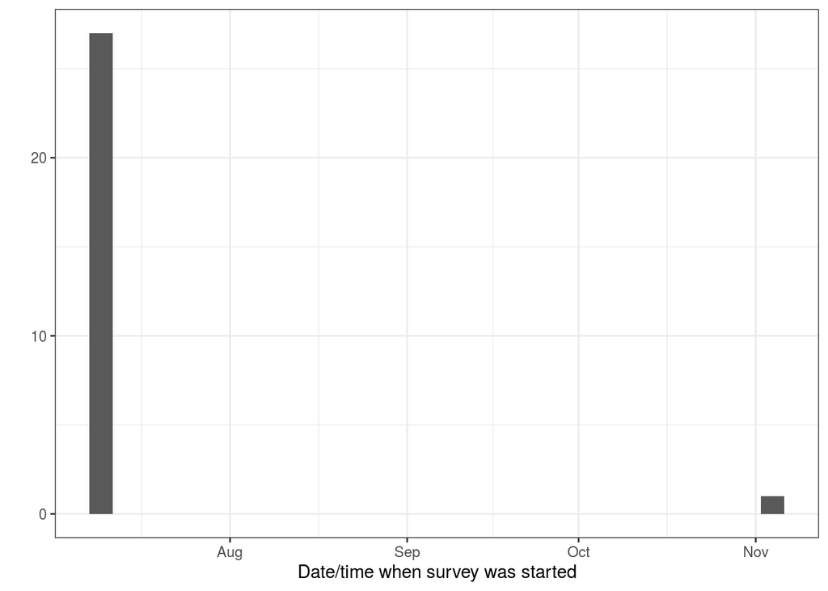

```r
ggplot2::qplot(results$created) + ggplot2::scale_x_datetime("Date/time when survey was started")
```

People took on average 127.36 minutes (median 1.48) to answer the survey.

```r
if (low_vals == 0) {
  warning("Durations below 0 detected.")
}
```

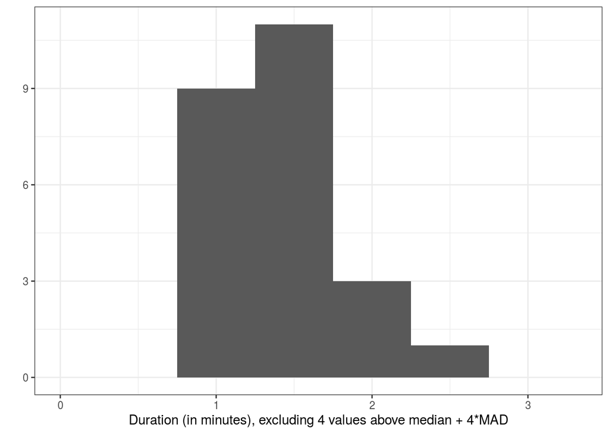

```r
ggplot2::qplot(duration$duration, binwidth = 0.5) + ggplot2::scale_x_continuous(paste("Duration (in minutes), excluding", high_vals, "values above median + 4*MAD"), limits = c(lower_limit, upper_limit))
```

## Variables

```r
if (detailed_variables || detailed_scales) {
  knitr::asis_output(paste0(scales_items, sep = "\n\n\n", collapse = "\n\n\n"))
}
```

### Scale: BFIK_agree

#### Overview

**Reliability**: ω<sub>ordinal</sub> [95% CI] = 0.61 [0.37;0.84].

**Missing**: 0.

```r
old_height <- knitr::opts_chunk$get("fig.height")
new_height <- length(scale_info$scale_item_names)
new_height <- ifelse(new_height > 20, 20, new_height)
new_height <- ifelse(new_height < 1, 1, new_height)
new_height <- ifelse(is.na(new_height) | is.nan(new_height),
                     old_height, new_height)
knitr::opts_chunk$set(fig.height = new_height)
```

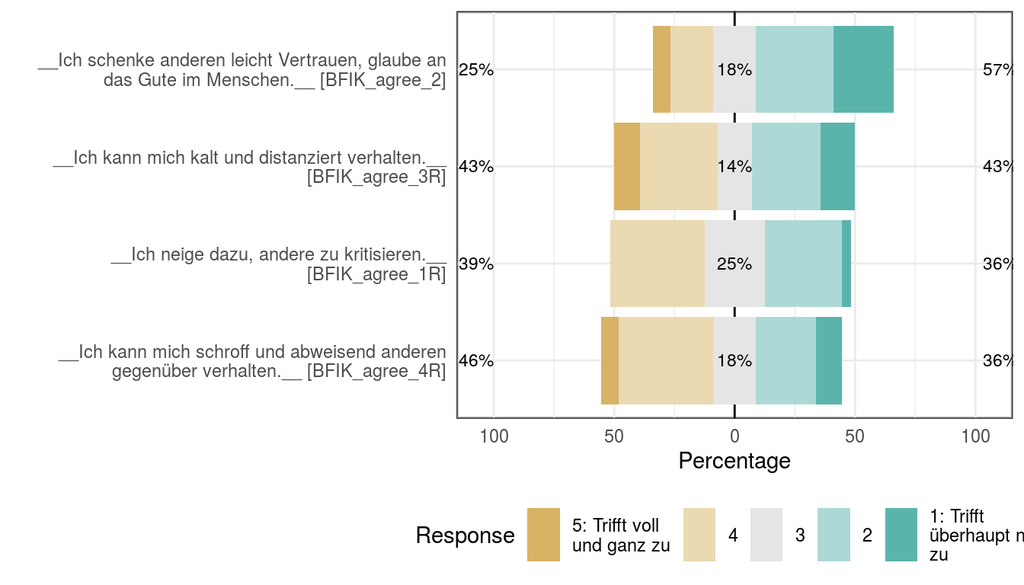

```r
if (dplyr::n_distinct(na.omit(unlist(items))) < 12) {
  likert_plot <- likert_from_items(items)
  if (!is.null(likert_plot)) {
    graphics::plot(likert_plot)
  }
}
```

```r
knitr::opts_chunk$set(fig.height = old_height)
```

```r
wrap_at <- knitr::opts_chunk$get("fig.width") * 10
```

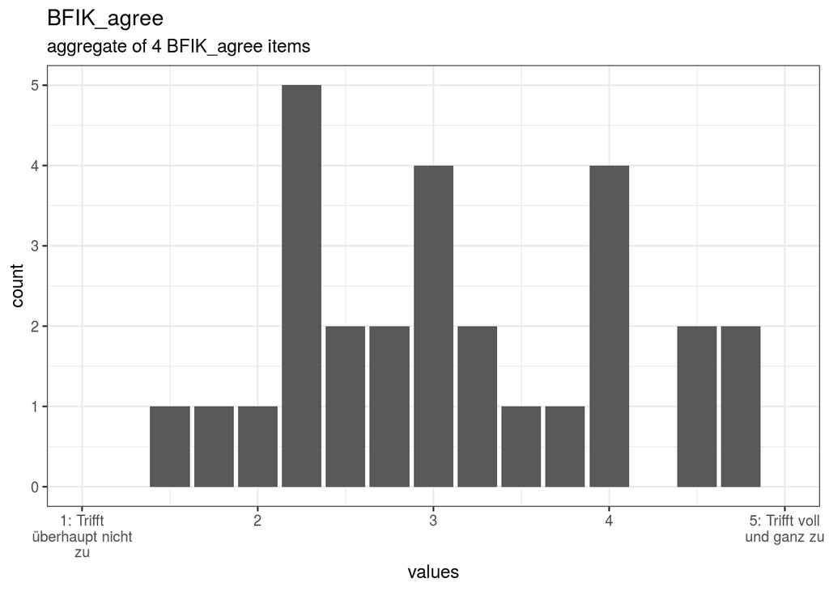

```r
dist_plot <- plot_labelled(scale, scale_name, wrap_at)

choices <- attributes(items[[1]])$item$choices
breaks <- as.numeric(names(choices))
if (length(breaks)) {
  suppressMessages( # ignore message about overwriting x axis
  dist_plot <- dist_plot +
        ggplot2::scale_x_continuous("values",
                                breaks = breaks,
                                labels = stringr::str_wrap(unlist(choices), ceiling(wrap_at * 0.21))) +
      ggplot2::expand_limits(x = range(breaks)))

}

dist_plot
```

#### Reliability details

```r
for (i in seq_along(reliabilities)) {
  rel <- reliabilities[[i]]
  cat(knitr::knit_print(rel, indent = paste0(indent, "####")))
}
```

##### Reliability Indices

```r
coefs <- x$scaleReliability$output$dat %>%
  tidyr::gather(index, estimate) %>%
  dplyr::filter(index != "n.items", index != "n.observations") %>%
  dplyr::mutate(index = stringr::str_to_title(
    stringr::str_replace_all(index,
      stringr::fixed("."), " ")))

cis <- coefs %>%
  dplyr::filter(stringr::str_detect(index, " Ci ")) %>%
  tidyr::separate(index, c("index", "hilo"), sep = " Ci ") %>%
  tidyr::spread(hilo, estimate)
if (nrow(cis)) {
  cis <- cis %>% dplyr::rename(
    `Lower 95% CI` = .data$Lo, `Upper 95% CI` = .data$Hi
  )
}

coefs_with_cis <- coefs %>%
  dplyr::filter(!stringr::str_detect(index, " Ci ")) %>%
    dplyr::left_join(cis, by = "index") %>%
    dplyr::mutate(index = dplyr::if_else(index == "Glb", "Greatest Lower Bound", .data$index)) %>%
    dplyr::arrange(!stringr::str_detect(index, "Omega")) %>%
    dplyr::select(Index = .data$index, Estimate = .data$estimate)


pander::pander(coefs_with_cis)
```

| Index | Estimate |
| --- | --- |
| Omega | 0.8193 |
| Omega Psych Tot | 0.8878 |
| Omega Psych H | 0.7664 |
| Omega Ordinal | 0.605 |
| Cronbach Alpha | 0.8006 |
| Greatest Lower Bound | 0.8858 |
| Alpha Ordinal | 0.5879 |

Positive correlations: 6 out of 6 (100%)

##### Scatter matrix

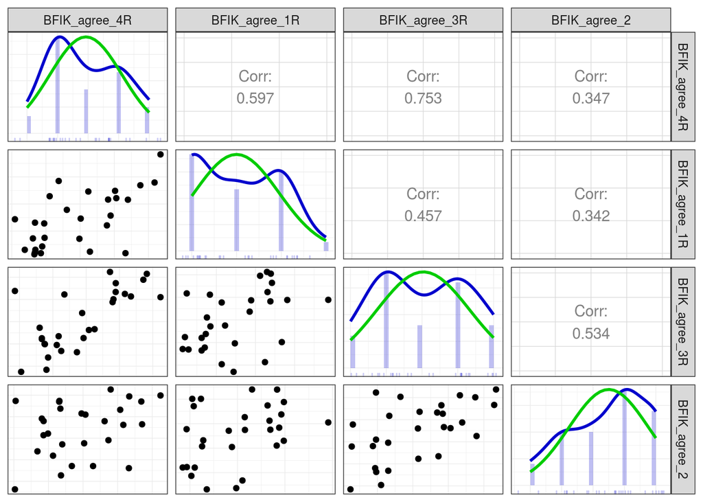

```r
print(x$scatterMatrix$output$scatterMatrix)
```

```r
x$scatterMatrix$output$scatterMatrix <- no_md()
```

**Detailed output**

```r
print(x)
```

```
##
## Information about this analysis:
##
##                  Dataframe: res$dat
##                      Items: BFIK_agree_4R, BFIK_agree_1R, BFIK_agree_3R, BFIK_agree_2
##               Observations: 28
##      Positive correlations: 6 out of 6 (100%)
##
## Estimates assuming interval level:
##
##              Omega (total): 0.82
##       Omega (hierarchical): 0.77
##    Revelle's omega (total): 0.89
## Greatest Lower Bound (GLB): 0.89
##              Coefficient H: 0.88
##           Cronbach's alpha: 0.8
## Confidence intervals:
##              Omega (total): [0.71, 0.93]
##           Cronbach's alpha: [0.68, 0.92]
##
## Estimates assuming ordinal level:
##
##      Ordinal Omega (total): 0.61
##  Ordinal Omega (hierarch.): 0.59
##   Ordinal Cronbach's alpha: 0.59
## Confidence intervals:
##      Ordinal Omega (total): [0.37, 0.84]
##   Ordinal Cronbach's alpha: [0.33, 0.84]
##
## Note: the normal point estimate and confidence interval for omega are based on the procedure suggested by Dunn, Baguley & Brunsden (2013) using the MBESS function ci.reliability, whereas the psych package point estimate was suggested in Revelle & Zinbarg (2008). See the help ('?scaleStructure') f…
##
## Eigen values: 2.539, 0.732, 0.54, 0.189
## Loadings:
##               PC1
## BFIK_agree_4R 0.871
## BFIK_agree_1R 0.748
## BFIK_agree_3R 0.880
## BFIK_agree_2  0.668
##
##                  PC1
## SS loadings    2.539
## Proportion Var 0.635
##
##               vars  n mean   sd median trimmed  mad min max range  skew
## BFIK_agree_4R    1 28 2.93 1.18      3    2.92 1.48   1   5     4  0.26
## BFIK_agree_1R    2 28 3.00 0.94      3    2.96 1.48   2   5     3  0.26
## BFIK_agree_3R    3 28 3.04 1.29      3    3.04 1.48   1   5     4  0.04
## BFIK_agree_2     4 28 3.50 1.26      4    3.58 1.48   1   5     4 -0.43
##               kurtosis   se
## BFIK_agree_4R    -1.18 0.22
## BFIK_agree_1R    -1.37 0.18
## BFIK_agree_3R    -1.35 0.24
## BFIK_agree_2     -1.03 0.24
```

#### Summary statistics

```r
for (i in seq_along(names(items))) {
  attributes(items[[i]]) = recursive_escape(attributes(items[[i]]))
}
escaped_table(codebook_table(items))
```

| name | label | type | type_options | data_type | value_labels | optional | item_order | missing | complete | n | mean | sd | p0 | p25 | p50 | p75 | p100 | hist |
| --- | --- | --- | --- | --- | --- | --- | --- | --- | --- | --- | --- | --- | --- | --- | --- | --- | --- | --- |
| BFIK_agree_4R | **Ich kann mich schroff und abweisend anderen gegenüber verhalten.** | rating_button | 5 | numeric | 5. 1: Trifft überhaupt nicht zu, 4. 2, 3. 3, 2. 4, 1. 5: Trifft voll und ganz zu, NA. Item was never rendered for this user. | 0 | 5 | 0 | 28 | 28 | 2.93 | 1.18 | 1 | 2 | 3 | 4 | 5 | ▂▇▁▃▁▅▁▂ |
| BFIK_agree_1R | **Ich neige dazu, andere zu kritisieren.** | rating_button | 5 | numeric | 5. 1: Trifft überhaupt nicht zu, 4. 2, 3. 3, 2. 4, 1. 5: Trifft voll und ganz zu, NA. Item was never rendered for this user. | 0 | 7 | 0 | 28 | 28 | 3 | 0.94 | 2 | 2 | 3 | 4 | 5 | ▇▁▅▁▁▆▁▁ |
| BFIK_agree_3R | **Ich kann mich kalt und distanziert verhalten.** | rating_button | 5 | numeric | 5. 1: Trifft überhaupt nicht zu, 4. 2, 3. 3, 2. 4, 1. 5: Trifft voll und ganz zu, NA. Item was never rendered for this user. | 0 | 13 | 0 | 28 | 28 | 3.04 | 1.29 | 1 | 2 | 3 | 4 | 5 | ▂▇▁▃▁▇▁▃ |
| BFIK_agree_2 | **Ich schenke anderen leicht Vertrauen, glaube an das Gute im Menschen.** | rating_button | 5 | numeric | 1. 1: Trifft überhaupt nicht zu, 2. 2, 3. 3, 4. 4, 5. 5: Trifft voll und ganz zu, NA. Item was never rendered for this user. | 0 | 17 | 0 | 28 | 28 | 3.5 | 1.26 | 1 | 2.75 | 4 | 4.25 | 5 | ▂▅▁▅▁▇▁▆ |

### Scale: BFIK_open

#### Overview

**Reliability**: Not computed.

**Missing**: 0.

```r
old_height <- knitr::opts_chunk$get("fig.height")
new_height <- length(scale_info$scale_item_names)
new_height <- ifelse(new_height > 20, 20, new_height)
new_height <- ifelse(new_height < 1, 1, new_height)
new_height <- ifelse(is.na(new_height) | is.nan(new_height),
                     old_height, new_height)
knitr::opts_chunk$set(fig.height = new_height)
```

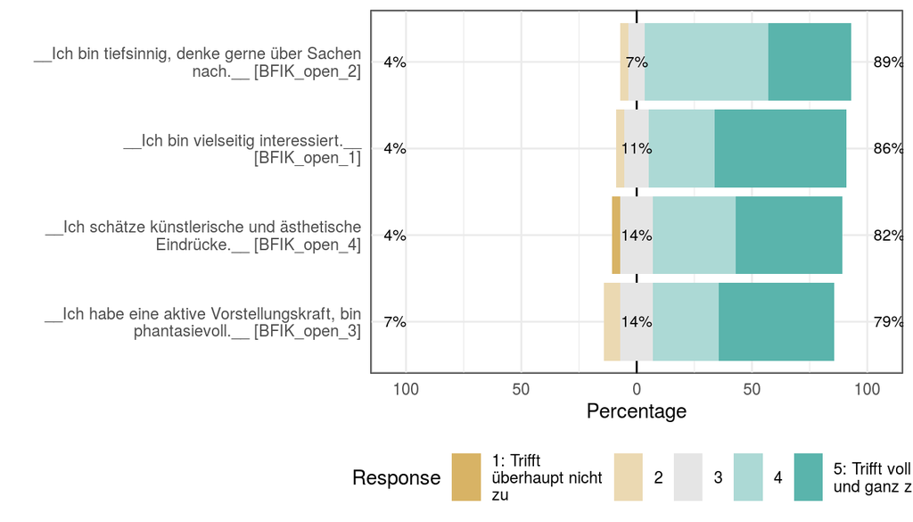

```r
if (dplyr::n_distinct(na.omit(unlist(items))) < 12) {
  likert_plot <- likert_from_items(items)
  if (!is.null(likert_plot)) {
    graphics::plot(likert_plot)
  }
}
```

```r
knitr::opts_chunk$set(fig.height = old_height)
```

```r
wrap_at <- knitr::opts_chunk$get("fig.width") * 10
```

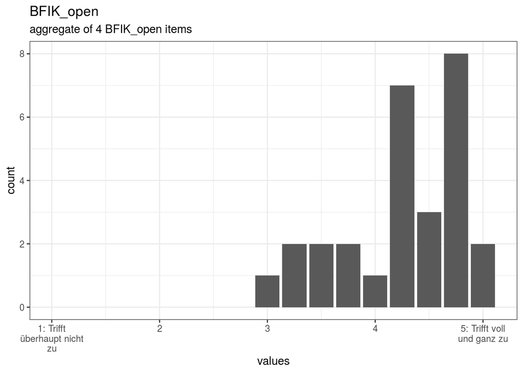

```r
dist_plot <- plot_labelled(scale, scale_name, wrap_at)

choices <- attributes(items[[1]])$item$choices
breaks <- as.numeric(names(choices))
if (length(breaks)) {
  suppressMessages( # ignore message about overwriting x axis
  dist_plot <- dist_plot +
        ggplot2::scale_x_continuous("values",
                                breaks = breaks,
                                labels = stringr::str_wrap(unlist(choices), ceiling(wrap_at * 0.21))) +
      ggplot2::expand_limits(x = range(breaks)))

}

dist_plot
```

#### Reliability details

```r
for (i in seq_along(reliabilities)) {
  rel <- reliabilities[[i]]
  cat(knitr::knit_print(rel, indent = paste0(indent, "####")))
}
```

#### Summary statistics

```r
for (i in seq_along(names(items))) {
  attributes(items[[i]]) = recursive_escape(attributes(items[[i]]))
}
escaped_table(codebook_table(items))
```

| name | label | type | type_options | data_type | value_labels | optional | item_order | missing | complete | n | mean | sd | p0 | p25 | p50 | p75 | p100 | hist |
| --- | --- | --- | --- | --- | --- | --- | --- | --- | --- | --- | --- | --- | --- | --- | --- | --- | --- | --- |
| BFIK_open_2 | **Ich bin tiefsinnig, denke gerne über Sachen nach.** | rating_button | 5 | numeric | 1. 1: Trifft überhaupt nicht zu, 2. 2, 3. 3, 4. 4, 5. 5: Trifft voll und ganz zu, NA. Item was never rendered for this user. | 0 | 4 | 0 | 28 | 28 | 4.21 | 0.74 | 2 | 4 | 4 | 5 | 5 | ▁▁▁▁▁▇▁▅ |
| BFIK_open_1 | **Ich bin vielseitig interessiert.** | rating_button | 5 | numeric | 1. 1: Trifft überhaupt nicht zu, 2. 2, 3. 3, 4. 4, 5. 5: Trifft voll und ganz zu, NA. Item was never rendered for this user. | 0 | 8 | 0 | 28 | 28 | 4.39 | 0.83 | 2 | 4 | 5 | 5 | 5 | ▁▁▂▁▁▃▁▇ |
| BFIK_open_4 | **Ich schätze künstlerische und ästhetische Eindrücke.** | rating_button | 5 | numeric | 1. 1: Trifft überhaupt nicht zu, 2. 2, 3. 3, 4. 4, 5. 5: Trifft voll und ganz zu, NA. Item was never rendered for this user. | 0 | 19 | 0 | 28 | 28 | 4.21 | 0.96 | 1 | 4 | 4 | 5 | 5 | ▁▁▁▂▁▆▁▇ |
| BFIK_open_3 | **Ich habe eine aktive Vorstellungskraft, bin phantasievoll.** | rating_button | 5 | numeric | 1. 1: Trifft überhaupt nicht zu, 2. 2, 3. 3, 4. 4, 5. 5: Trifft voll und ganz zu, NA. Item was never rendered for this user. | 0 | 22 | 0 | 28 | 28 | 4.21 | 0.96 | 2 | 4 | 4.5 | 5 | 5 | ▁▁▂▁▁▅▁▇ |

### Scale: BFIK_consc

#### Overview

**Reliability**: ω<sub>ordinal</sub> [95% CI] = 0.61 [0.38;0.84].

**Missing**: 0.

```r
old_height <- knitr::opts_chunk$get("fig.height")
new_height <- length(scale_info$scale_item_names)
new_height <- ifelse(new_height > 20, 20, new_height)
new_height <- ifelse(new_height < 1, 1, new_height)
new_height <- ifelse(is.na(new_height) | is.nan(new_height),
                     old_height, new_height)
knitr::opts_chunk$set(fig.height = new_height)
```

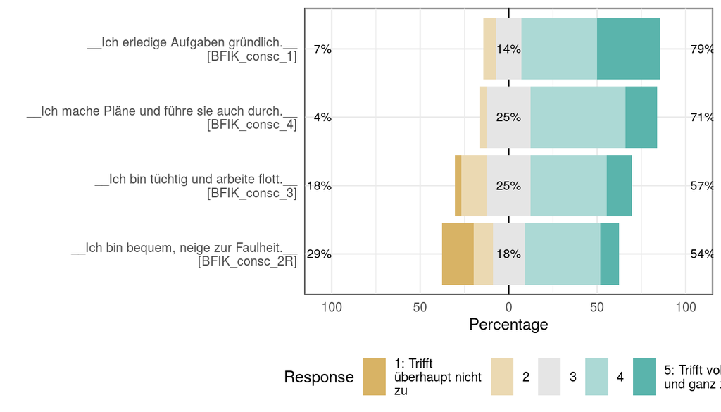

```r
if (dplyr::n_distinct(na.omit(unlist(items))) < 12) {
  likert_plot <- likert_from_items(items)
  if (!is.null(likert_plot)) {
    graphics::plot(likert_plot)
  }
}
```

```r
knitr::opts_chunk$set(fig.height = old_height)
```

```r
wrap_at <- knitr::opts_chunk$get("fig.width") * 10
```

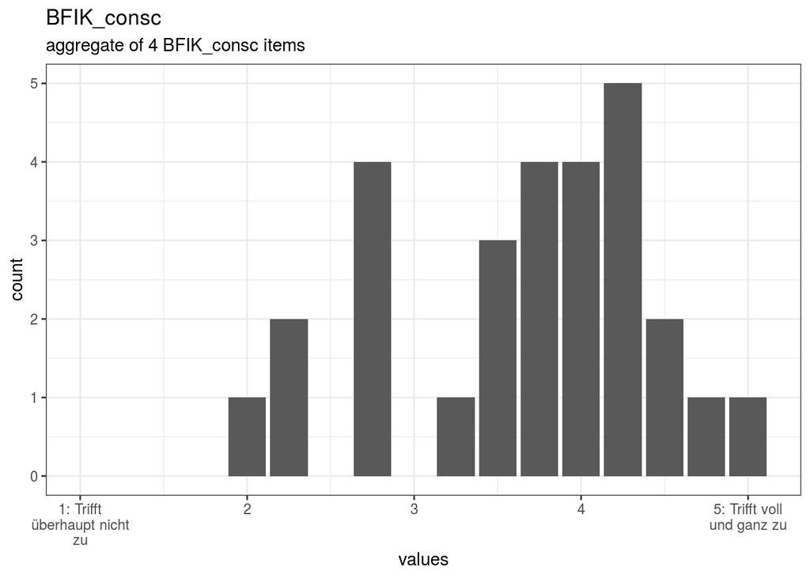

```r
dist_plot <- plot_labelled(scale, scale_name, wrap_at)

choices <- attributes(items[[1]])$item$choices
breaks <- as.numeric(names(choices))
if (length(breaks)) {
  suppressMessages( # ignore message about overwriting x axis
  dist_plot <- dist_plot +
        ggplot2::scale_x_continuous("values",
                                breaks = breaks,
                                labels = stringr::str_wrap(unlist(choices), ceiling(wrap_at * 0.21))) +
      ggplot2::expand_limits(x = range(breaks)))

}

dist_plot
```

#### Reliability details

```r
for (i in seq_along(reliabilities)) {
  rel <- reliabilities[[i]]
  cat(knitr::knit_print(rel, indent = paste0(indent, "####")))
}
```

##### Reliability Indices

```r
coefs <- x$scaleReliability$output$dat %>%
  tidyr::gather(index, estimate) %>%
  dplyr::filter(index != "n.items", index != "n.observations") %>%
  dplyr::mutate(index = stringr::str_to_title(
    stringr::str_replace_all(index,
      stringr::fixed("."), " ")))

cis <- coefs %>%
  dplyr::filter(stringr::str_detect(index, " Ci ")) %>%
  tidyr::separate(index, c("index", "hilo"), sep = " Ci ") %>%
  tidyr::spread(hilo, estimate)
if (nrow(cis)) {
  cis <- cis %>% dplyr::rename(
    `Lower 95% CI` = .data$Lo, `Upper 95% CI` = .data$Hi
  )
}

coefs_with_cis <- coefs %>%
  dplyr::filter(!stringr::str_detect(index, " Ci ")) %>%
    dplyr::left_join(cis, by = "index") %>%
    dplyr::mutate(index = dplyr::if_else(index == "Glb", "Greatest Lower Bound", .data$index)) %>%
    dplyr::arrange(!stringr::str_detect(index, "Omega")) %>%
    dplyr::select(Index = .data$index, Estimate = .data$estimate)


pander::pander(coefs_with_cis)
```

| Index | Estimate |
| --- | --- |
| Omega | 0.812 |
| Omega Psych Tot | 0.3688 |
| Omega Psych H | 0.2444 |
| Omega Ordinal | 0.6077 |
| Cronbach Alpha | 0.7797 |
| Greatest Lower Bound | 0.9018 |
| Alpha Ordinal | 0.5935 |

Positive correlations: 6 out of 6 (100%)

##### Scatter matrix

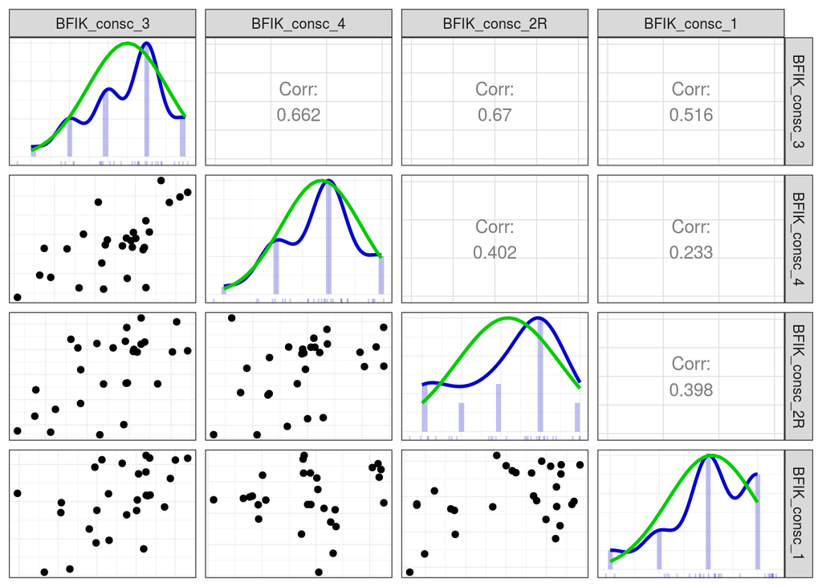

```r
print(x$scatterMatrix$output$scatterMatrix)
```

```r
x$scatterMatrix$output$scatterMatrix <- no_md()
```

**Detailed output**

```r
print(x)
```

```
##
## Information about this analysis:
##
##                  Dataframe: res$dat
##                      Items: BFIK_consc_3, BFIK_consc_4, BFIK_consc_2R, BFIK_consc_1
##               Observations: 28
##      Positive correlations: 6 out of 6 (100%)
##
## Estimates assuming interval level:
##
##              Omega (total): 0.81
##       Omega (hierarchical): 0.24
##    Revelle's omega (total): 0.37
## Greatest Lower Bound (GLB): 0.9
##              Coefficient H: 1
##           Cronbach's alpha: 0.78
## Confidence intervals:
##              Omega (total): [0.7, 0.92]
##           Cronbach's alpha: [0.65, 0.91]
##
## Estimates assuming ordinal level:
##
##      Ordinal Omega (total): 0.61
##  Ordinal Omega (hierarch.): 0.59
##   Ordinal Cronbach's alpha: 0.59
## Confidence intervals:
##      Ordinal Omega (total): [0.38, 0.84]
##   Ordinal Cronbach's alpha: [0.34, 0.84]
##
## Note: the normal point estimate and confidence interval for omega are based on the procedure suggested by Dunn, Baguley & Brunsden (2013) using the MBESS function ci.reliability, whereas the psych package point estimate was suggested in Revelle & Zinbarg (2008). See the help ('?scaleStructure') f…
##
## Eigen values: 2.473, 0.777, 0.539, 0.211
## Loadings:
##               PC1
## BFIK_consc_3  0.926
## BFIK_consc_4  0.738
## BFIK_consc_2R 0.800
## BFIK_consc_1  0.657
##
##                  PC1
## SS loadings    2.473
## Proportion Var 0.618
##
##               vars  n mean   sd median trimmed  mad min max range  skew
## BFIK_consc_3     1 28 3.50 1.04      4    3.54 1.48   1   5     4 -0.48
## BFIK_consc_4     2 28 3.86 0.76      4    3.88 0.00   2   5     3 -0.27
## BFIK_consc_2R    3 28 3.18 1.31      4    3.21 1.48   1   5     4 -0.51
## BFIK_consc_1     4 28 4.07 0.90      4    4.17 1.48   2   5     3 -0.72
##               kurtosis   se
## BFIK_consc_3     -0.50 0.20
## BFIK_consc_4     -0.35 0.14
## BFIK_consc_2R    -1.08 0.25
## BFIK_consc_1     -0.30 0.17
```

#### Summary statistics

```r
for (i in seq_along(names(items))) {
  attributes(items[[i]]) = recursive_escape(attributes(items[[i]]))
}
escaped_table(codebook_table(items))
```

| name | label | type | type_options | data_type | value_labels | optional | item_order | missing | complete | n | mean | sd | p0 | p25 | p50 | p75 | p100 | hist |
| --- | --- | --- | --- | --- | --- | --- | --- | --- | --- | --- | --- | --- | --- | --- | --- | --- | --- | --- |
| BFIK_consc_3 | **Ich bin tüchtig und arbeite flott.** | rating_button | 5 | numeric | 1. 1: Trifft überhaupt nicht zu, 2. 2, 3. 3, 4. 4, 5. 5: Trifft voll und ganz zu, NA. Item was never rendered for this user. | 0 | 10 | 0 | 28 | 28 | 3.5 | 1.04 | 1 | 3 | 4 | 4 | 5 | ▁▂▁▅▁▇▁▂ |
| BFIK_consc_4 | **Ich mache Pläne und führe sie auch durch.** | rating_button | 5 | numeric | 1. 1: Trifft überhaupt nicht zu, 2. 2, 3. 3, 4. 4, 5. 5: Trifft voll und ganz zu, NA. Item was never rendered for this user. | 0 | 11 | 0 | 28 | 28 | 3.86 | 0.76 | 2 | 3 | 4 | 4 | 5 | ▁▁▃▁▁▇▁▂ |
| BFIK_consc_2R | **Ich bin bequem, neige zur Faulheit.** | rating_button | 5 | numeric | 5. 1: Trifft überhaupt nicht zu, 4. 2, 3. 3, 2. 4, 1. 5: Trifft voll und ganz zu, NA. Item was never rendered for this user. | 0 | 12 | 0 | 28 | 28 | 3.18 | 1.31 | 1 | 2 | 4 | 4 | 5 | ▃▂▁▃▁▇▁▂ |
| BFIK_consc_1 | **Ich erledige Aufgaben gründlich.** | rating_button | 5 | numeric | 1. 1: Trifft überhaupt nicht zu, 2. 2, 3. 3, 4. 4, 5. 5: Trifft voll und ganz zu, NA. Item was never rendered for this user. | 0 | 18 | 0 | 28 | 28 | 4.07 | 0.9 | 2 | 4 | 4 | 5 | 5 | ▁▁▂▁▁▇▁▇ |

### Scale: BFIK_extra

#### Overview

**Reliability**: ω<sub>ordinal</sub> [95% CI] = 0.78 [0.64;0.91].

**Missing**: 0.

```r
old_height <- knitr::opts_chunk$get("fig.height")
new_height <- length(scale_info$scale_item_names)
new_height <- ifelse(new_height > 20, 20, new_height)
new_height <- ifelse(new_height < 1, 1, new_height)
new_height <- ifelse(is.na(new_height) | is.nan(new_height),
                     old_height, new_height)
knitr::opts_chunk$set(fig.height = new_height)
```

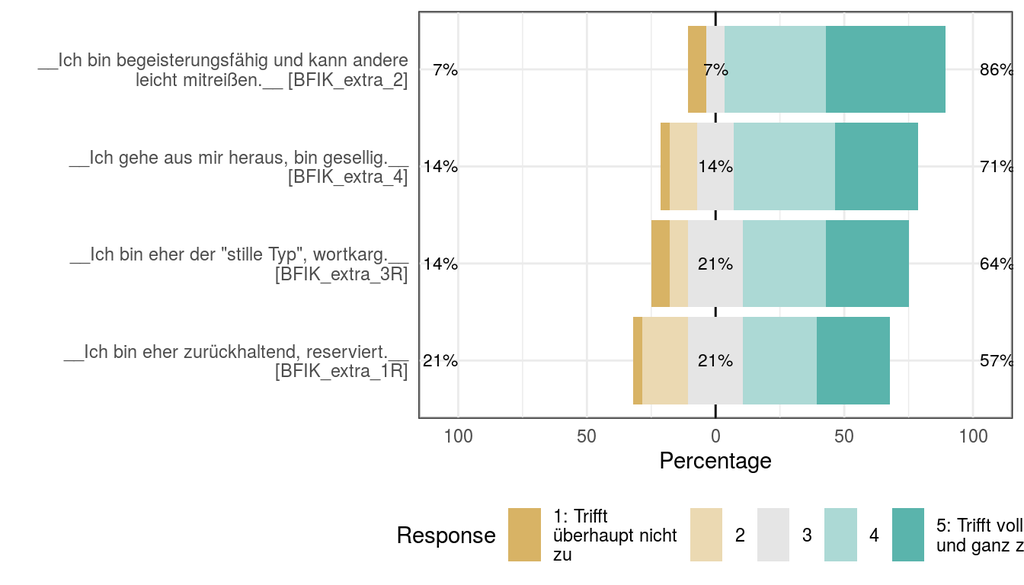

```r
if (dplyr::n_distinct(na.omit(unlist(items))) < 12) {
  likert_plot <- likert_from_items(items)
  if (!is.null(likert_plot)) {
    graphics::plot(likert_plot)
  }
}
```

```r
knitr::opts_chunk$set(fig.height = old_height)
```

```r
wrap_at <- knitr::opts_chunk$get("fig.width") * 10
```

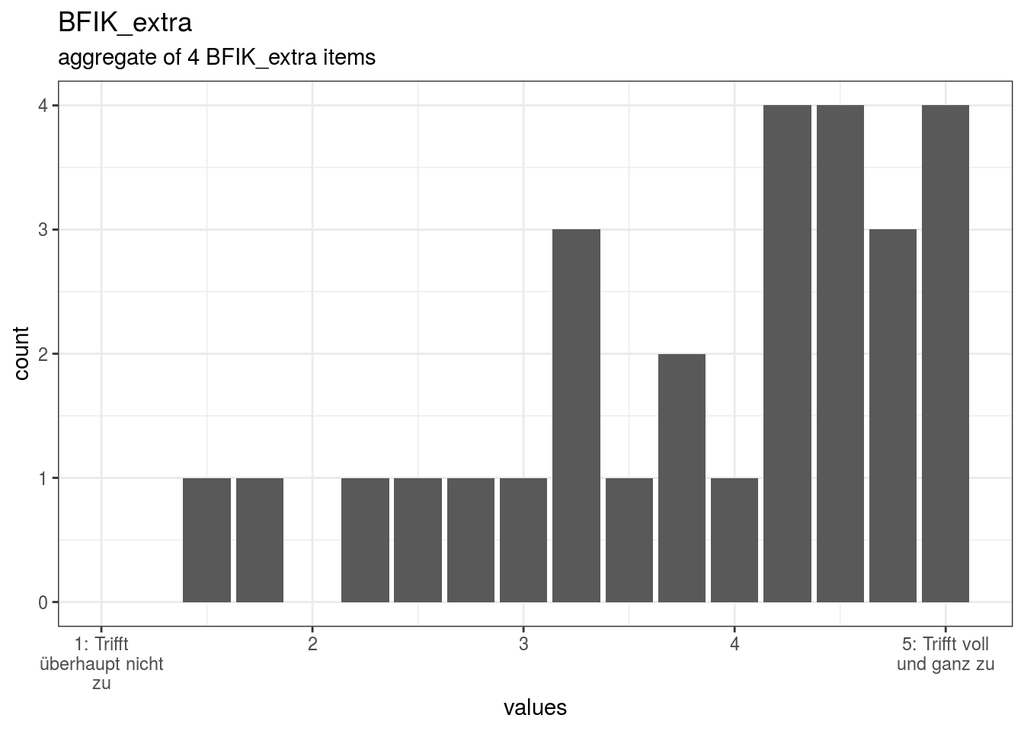

```r
dist_plot <- plot_labelled(scale, scale_name, wrap_at)

choices <- attributes(items[[1]])$item$choices
breaks <- as.numeric(names(choices))
if (length(breaks)) {
  suppressMessages( # ignore message about overwriting x axis
  dist_plot <- dist_plot +
        ggplot2::scale_x_continuous("values",
                                breaks = breaks,
                                labels = stringr::str_wrap(unlist(choices), ceiling(wrap_at * 0.21))) +
      ggplot2::expand_limits(x = range(breaks)))

}

dist_plot
```

#### Reliability details

```r
for (i in seq_along(reliabilities)) {
  rel <- reliabilities[[i]]
  cat(knitr::knit_print(rel, indent = paste0(indent, "####")))
}
```

##### Reliability Indices

```r
coefs <- x$scaleReliability$output$dat %>%
  tidyr::gather(index, estimate) %>%
  dplyr::filter(index != "n.items", index != "n.observations") %>%
  dplyr::mutate(index = stringr::str_to_title(
    stringr::str_replace_all(index,
      stringr::fixed("."), " ")))

cis <- coefs %>%
  dplyr::filter(stringr::str_detect(index, " Ci ")) %>%
  tidyr::separate(index, c("index", "hilo"), sep = " Ci ") %>%
  tidyr::spread(hilo, estimate)
if (nrow(cis)) {
  cis <- cis %>% dplyr::rename(
    `Lower 95% CI` = .data$Lo, `Upper 95% CI` = .data$Hi
  )
}

coefs_with_cis <- coefs %>%
  dplyr::filter(!stringr::str_detect(index, " Ci ")) %>%
    dplyr::left_join(cis, by = "index") %>%
    dplyr::mutate(index = dplyr::if_else(index == "Glb", "Greatest Lower Bound", .data$index)) %>%
    dplyr::arrange(!stringr::str_detect(index, "Omega")) %>%
    dplyr::select(Index = .data$index, Estimate = .data$estimate)


pander::pander(coefs_with_cis)
```

| Index | Estimate |
| --- | --- |
| Omega | 0.9023 |
| Omega Psych Tot | 0.9589 |
| Omega Psych H | 0.8395 |
| Omega Ordinal | 0.775 |
| Cronbach Alpha | 0.8993 |
| Greatest Lower Bound | 0.9581 |
| Alpha Ordinal | 0.7744 |

Positive correlations: 6 out of 6 (100%)

##### Scatter matrix

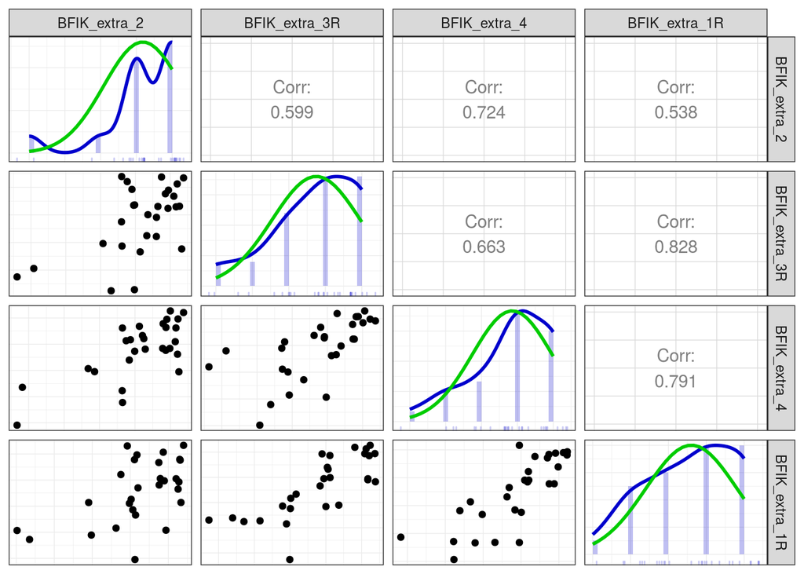

```r
print(x$scatterMatrix$output$scatterMatrix)
```

```r
x$scatterMatrix$output$scatterMatrix <- no_md()
```

**Detailed output**

```r
print(x)
```

```
##
## Information about this analysis:
##
##                  Dataframe: res$dat
##                      Items: BFIK_extra_2, BFIK_extra_3R, BFIK_extra_4, BFIK_extra_1R
##               Observations: 28
##      Positive correlations: 6 out of 6 (100%)
##
## Estimates assuming interval level:
##
##              Omega (total): 0.9
##       Omega (hierarchical): 0.84
##    Revelle's omega (total): 0.96
## Greatest Lower Bound (GLB): 0.96
##              Coefficient H: 0.93
##           Cronbach's alpha: 0.9
## Confidence intervals:
##              Omega (total): [0.84, 0.96]
##           Cronbach's alpha: [0.83, 0.96]
##
## Estimates assuming ordinal level:
##
##      Ordinal Omega (total): 0.78
##  Ordinal Omega (hierarch.): 0.75
##   Ordinal Cronbach's alpha: 0.77
## Confidence intervals:
##      Ordinal Omega (total): [0.64, 0.91]
##   Ordinal Cronbach's alpha: [0.64, 0.91]
##
## Note: the normal point estimate and confidence interval for omega are based on the procedure suggested by Dunn, Baguley & Brunsden (2013) using the MBESS function ci.reliability, whereas the psych package point estimate was suggested in Revelle & Zinbarg (2008). See the help ('?scaleStructure') f…
##
## Eigen values: 3.077, 0.527, 0.297, 0.099
## Loadings:
##               PC1
## BFIK_extra_2  0.806
## BFIK_extra_3R 0.883
## BFIK_extra_4  0.908
## BFIK_extra_1R 0.907
##
##                  PC1
## SS loadings    3.077
## Proportion Var 0.769
##
##               vars  n mean   sd median trimmed  mad min max range  skew
## BFIK_extra_2     1 28 4.18 1.09      4    4.38 1.48   1   5     4 -1.66
## BFIK_extra_3R    2 28 3.75 1.21      4    3.88 1.48   1   5     4 -0.76
## BFIK_extra_4     3 28 3.86 1.11      4    3.96 1.48   1   5     4 -0.82
## BFIK_extra_1R    4 28 3.61 1.20      4    3.67 1.48   1   5     4 -0.37
##               kurtosis   se
## BFIK_extra_2      2.40 0.21
## BFIK_extra_3R    -0.35 0.23
## BFIK_extra_4     -0.21 0.21
## BFIK_extra_1R    -1.07 0.23
```

#### Summary statistics

```r
for (i in seq_along(names(items))) {
  attributes(items[[i]]) = recursive_escape(attributes(items[[i]]))
}
escaped_table(codebook_table(items))
```

| name | label | type | type_options | data_type | value_labels | optional | item_order | missing | complete | n | mean | sd | p0 | p25 | p50 | p75 | p100 | hist |
| --- | --- | --- | --- | --- | --- | --- | --- | --- | --- | --- | --- | --- | --- | --- | --- | --- | --- | --- |
| BFIK_extra_2 | **Ich bin begeisterungsfähig und kann andere leicht mitreißen.** | rating_button | 5 | numeric | 1. 1: Trifft überhaupt nicht zu, 2. 2, 3. 3, 4. 4, 5. 5: Trifft voll und ganz zu, NA. Item was never rendered for this user. | 0 | 6 | 0 | 28 | 28 | 4.18 | 1.09 | 1 | 4 | 4 | 5 | 5 | ▁▁▁▁▁▇▁▇ |
| BFIK_extra_3R | **Ich bin eher der “stille Typ”, wortkarg.** | rating_button | 5 | numeric | 5. 1: Trifft überhaupt nicht zu, 4. 2, 3. 3, 2. 4, 1. 5: Trifft voll und ganz zu, NA. Item was never rendered for this user. | 0 | 14 | 0 | 28 | 28 | 3.75 | 1.21 | 1 | 3 | 4 | 5 | 5 | ▂▂▁▅▁▇▁▇ |
| BFIK_extra_4 | **Ich gehe aus mir heraus, bin gesellig.** | rating_button | 5 | numeric | 1. 1: Trifft überhaupt nicht zu, 2. 2, 3. 3, 4. 4, 5. 5: Trifft voll und ganz zu, NA. Item was never rendered for this user. | 0 | 20 | 0 | 28 | 28 | 3.86 | 1.11 | 1 | 3 | 4 | 5 | 5 | ▁▂▁▃▁▇▁▆ |
| BFIK_extra_1R | **Ich bin eher zurückhaltend, reserviert.** | rating_button | 5 | numeric | 5. 1: Trifft überhaupt nicht zu, 4. 2, 3. 3, 2. 4, 1. 5: Trifft voll und ganz zu, NA. Item was never rendered for this user. | 0 | 21 | 0 | 28 | 28 | 3.61 | 1.2 | 1 | 3 | 4 | 5 | 5 | ▁▅▁▆▁▇▁▇ |

### Scale: BFIK_neuro

#### Overview

**Reliability**: ω<sub>ordinal</sub> [95% CI] = 0.66 [0.43;0.9].

**Missing**: 0.

```r
old_height <- knitr::opts_chunk$get("fig.height")
new_height <- length(scale_info$scale_item_names)
new_height <- ifelse(new_height > 20, 20, new_height)
new_height <- ifelse(new_height < 1, 1, new_height)
new_height <- ifelse(is.na(new_height) | is.nan(new_height),
                     old_height, new_height)
knitr::opts_chunk$set(fig.height = new_height)
```

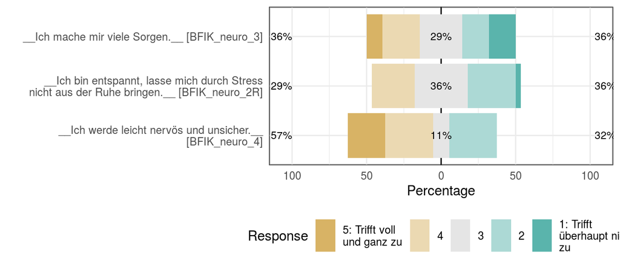

```r
if (dplyr::n_distinct(na.omit(unlist(items))) < 12) {
  likert_plot <- likert_from_items(items)
  if (!is.null(likert_plot)) {
    graphics::plot(likert_plot)
  }
}
```

```r
knitr::opts_chunk$set(fig.height = old_height)
```

```r
wrap_at <- knitr::opts_chunk$get("fig.width") * 10
```

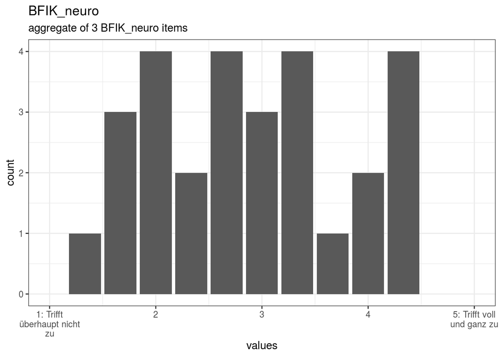

```r
dist_plot <- plot_labelled(scale, scale_name, wrap_at)

choices <- attributes(items[[1]])$item$choices
breaks <- as.numeric(names(choices))
if (length(breaks)) {
  suppressMessages( # ignore message about overwriting x axis
  dist_plot <- dist_plot +
        ggplot2::scale_x_continuous("values",
                                breaks = breaks,
                                labels = stringr::str_wrap(unlist(choices), ceiling(wrap_at * 0.21))) +
      ggplot2::expand_limits(x = range(breaks)))

}

dist_plot
```

#### Reliability details

```r
for (i in seq_along(reliabilities)) {
  rel <- reliabilities[[i]]
  cat(knitr::knit_print(rel, indent = paste0(indent, "####")))
}
```

##### Reliability Indices

```r
coefs <- x$scaleReliability$output$dat %>%
  tidyr::gather(index, estimate) %>%
  dplyr::filter(index != "n.items", index != "n.observations") %>%
  dplyr::mutate(index = stringr::str_to_title(
    stringr::str_replace_all(index,
      stringr::fixed("."), " ")))

cis <- coefs %>%
  dplyr::filter(stringr::str_detect(index, " Ci ")) %>%
  tidyr::separate(index, c("index", "hilo"), sep = " Ci ") %>%
  tidyr::spread(hilo, estimate)
if (nrow(cis)) {
  cis <- cis %>% dplyr::rename(
    `Lower 95% CI` = .data$Lo, `Upper 95% CI` = .data$Hi
  )
}

coefs_with_cis <- coefs %>%
  dplyr::filter(!stringr::str_detect(index, " Ci ")) %>%
    dplyr::left_join(cis, by = "index") %>%
    dplyr::mutate(index = dplyr::if_else(index == "Glb", "Greatest Lower Bound", .data$index)) %>%
    dplyr::arrange(!stringr::str_detect(index, "Omega")) %>%
    dplyr::select(Index = .data$index, Estimate = .data$estimate)


pander::pander(coefs_with_cis)
```

| Index | Estimate |
| --- | --- |
| Omega | 0.8191 |
| Omega Psych Tot | 0.7954 |
| Omega Psych H | 0.03191 |
| Omega Ordinal | 0.6649 |
| Cronbach Alpha | 0.7537 |
| Greatest Lower Bound | 0.8345 |
| Alpha Ordinal | 0.6022 |

Positive correlations: 3 out of 3 (100%)

##### Scatter matrix

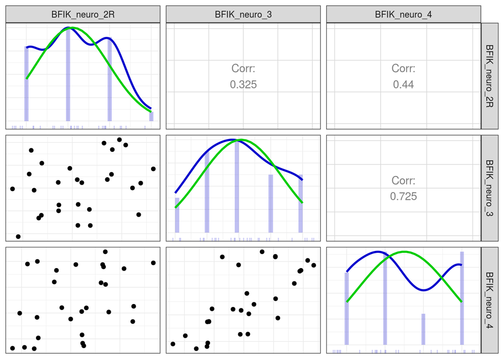

```r
print(x$scatterMatrix$output$scatterMatrix)
```

```r
x$scatterMatrix$output$scatterMatrix <- no_md()
```

**Detailed output**

```r
print(x)
```

```
##
## Information about this analysis:
##
##                  Dataframe: res$dat
##                      Items: BFIK_neuro_2R, BFIK_neuro_3, BFIK_neuro_4
##               Observations: 28
##      Positive correlations: 3 out of 3 (100%)
##
## Estimates assuming interval level:
##
##              Omega (total): 0.82
##       Omega (hierarchical): 0.03
##    Revelle's omega (total): 0.8
## Greatest Lower Bound (GLB): 0.83
##              Coefficient H: 0.98
##           Cronbach's alpha: 0.75
## Confidence intervals:
##              Omega (total): [0.71, 0.93]
##           Cronbach's alpha: [0.58, 0.92]
##
## Estimates assuming ordinal level:
##
##      Ordinal Omega (total): 0.66
##  Ordinal Omega (hierarch.): 0.64
##   Ordinal Cronbach's alpha: 0.6
## Confidence intervals:
##      Ordinal Omega (total): [0.43, 0.9]
##   Ordinal Cronbach's alpha: [0.34, 0.86]
##
## Note: the normal point estimate and confidence interval for omega are based on the procedure suggested by Dunn, Baguley & Brunsden (2013) using the MBESS function ci.reliability, whereas the psych package point estimate was suggested in Revelle & Zinbarg (2008). See the help ('?scaleStructure') f…
##
## Eigen values: 2.015, 0.723, 0.262
## Loadings:
##               PC1
## BFIK_neuro_2R 0.670
## BFIK_neuro_3  0.863
## BFIK_neuro_4  0.907
##
##                  PC1
## SS loadings    2.015
## Proportion Var 0.672
##
##               vars  n mean   sd median trimmed  mad min max range skew
## BFIK_neuro_2R    1 28 3.11 0.88      3    3.08 1.48   2   5     3 0.12
## BFIK_neuro_3     2 28 3.07 1.27      3    3.08 1.48   1   5     4 0.08
## BFIK_neuro_4     3 28 2.50 1.20      2    2.50 1.48   1   4     3 0.12
##               kurtosis   se
## BFIK_neuro_2R    -1.14 0.17
## BFIK_neuro_3     -1.14 0.24
## BFIK_neuro_4     -1.60 0.23
```

#### Summary statistics

```r
for (i in seq_along(names(items))) {
  attributes(items[[i]]) = recursive_escape(attributes(items[[i]]))
}
escaped_table(codebook_table(items))
```

| name | label | type | type_options | data_type | value_labels | optional | item_order | missing | complete | n | mean | sd | p0 | p25 | p50 | p75 | p100 | hist |
| --- | --- | --- | --- | --- | --- | --- | --- | --- | --- | --- | --- | --- | --- | --- | --- | --- | --- | --- |
| BFIK_neuro_2R | **Ich bin entspannt, lasse mich durch Stress nicht aus der Ruhe bringen.** | rating_button | 5 | numeric | 5. 1: Trifft überhaupt nicht zu, 4. 2, 3. 3, 2. 4, 1. 5: Trifft voll und ganz zu, NA. Item was never rendered for this user. | 0 | 9 | 0 | 28 | 28 | 3.11 | 0.88 | 2 | 2 | 3 | 4 | 5 | ▆▁▇▁▁▇▁▁ |
| BFIK_neuro_3 | **Ich mache mir viele Sorgen.** | rating_button | 5 | numeric | 1. 1: Trifft überhaupt nicht zu, 2. 2, 3. 3, 4. 4, 5. 5: Trifft voll und ganz zu, NA. Item was never rendered for this user. | 0 | 15 | 0 | 28 | 28 | 3.07 | 1.27 | 1 | 2 | 3 | 4 | 5 | ▃▇▁▇▁▅▁▅ |
| BFIK_neuro_4 | **Ich werde leicht nervös und unsicher.** | rating_button | 5 | numeric | 1. 1: Trifft überhaupt nicht zu, 2. 2, 3. 3, 4. 4, 5. 5: Trifft voll und ganz zu, NA. Item was never rendered for this user. | 0 | 16 | 0 | 28 | 28 | 2.5 | 1.2 | 1 | 1.75 | 2 | 4 | 4 | ▆▁▇▁▁▂▁▇ |

```r
missingness_report
```

## Missingness report

```r
if (length(md_pattern)) {
  if (knitr::is_html_output()) {
    rmarkdown::paged_table(md_pattern, options = list(rows.print = 10))
  } else {
    knitr::kable(md_pattern)
  }
}
```

| description | expired | var_miss | n_miss |
| --- | --- | --- | --- |
| Missing values in 1 variables | 0 | 1 | 28 |
| Missing values per variable | 28 | 28 | 28 |

```r
items
```

## Codebook table

```r
export_table(metadata_table)
```

| name | label | type | type_options | data_type | value_labels | optional | scale_item_names | item_order | missing | complete | n | empty | n_unique | count | median | min | max | mean | sd | p0 | p25 | p50 | p75 | p100 | hist |
| --- | --- | --- | --- | --- | --- | --- | --- | --- | --- | --- | --- | --- | --- | --- | --- | --- | --- | --- | --- | --- | --- | --- | --- | --- | --- |
| session |  |  |  | character |  |  |  |  | 0 | 28 | 28 | 0 | 28 |  |  | 64 | 64 |  |  |  |  |  |  |  |  |
| created | user first opened survey |  |  | POSIXct |  |  |  |  | 0 | 28 | 28 |  | 28 |  | 2016-07-08 | 2016-07-08 | 2016-11-02 |  |  |  |  |  |  |  |  |
| modified | user last edited survey |  |  | POSIXct |  |  |  |  | 0 | 28 | 28 |  | 28 |  | 2016-07-08 | 2016-07-08 | 2016-11-02 |  |  |  |  |  |  |  |  |
| ended | user finished survey |  |  | POSIXct |  |  |  |  | 0 | 28 | 28 |  | 28 |  | 2016-07-08 | 2016-07-08 | 2016-11-02 |  |  |  |  |  |  |  |  |
| expired |  |  |  | logical |  |  |  |  | 28 | 0 | 28 |  |  | 28 |  |  |  | NaN |  |  |  |  |  |  |  |
| BFIK_open_2 | __Ich bin tiefsinnig, denke gerne über Sachen nach.__ | rating_button | 5 | numeric | 1. 1: Trifft überhaupt nicht zu,2. 2,3. 3,4. 4,5. 5: Trifft voll und ganz zu,NA. Item was never rendered for this user. | 0 |  | 4 | 0 | 28 | 28 |  |  |  |  |  |  | 4.21 | 0.74 | 2 | 4 | 4 | 5 | 5 | ▁▁▁▁▁▇▁▅ |
| BFIK_agree_4R | __Ich kann mich schroff und abweisend anderen gegenüber verhalten.__ | rating_button | 5 | numeric | 5. 1: Trifft überhaupt nicht zu,4. 2,3. 3,2. 4,1. 5: Trifft voll und ganz zu,NA. Item was never rendered for this user. | 0 |  | 5 | 0 | 28 | 28 |  |  |  |  |  |  | 2.93 | 1.18 | 1 | 2 | 3 | 4 | 5 | ▂▇▁▃▁▅▁▂ |
| BFIK_extra_2 | __Ich bin begeisterungsfähig und kann andere leicht mitreißen.__ | rating_button | 5 | numeric | 1. 1: Trifft überhaupt nicht zu,2. 2,3. 3,4. 4,5. 5: Trifft voll und ganz zu,NA. Item was never rendered for this user. | 0 |  | 6 | 0 | 28 | 28 |  |  |  |  |  |  | 4.18 | 1.09 | 1 | 4 | 4 | 5 | 5 | ▁▁▁▁▁▇▁▇ |
| BFIK_agree_1R | __Ich neige dazu, andere zu kritisieren.__ | rating_button | 5 | numeric | 5. 1: Trifft überhaupt nicht zu,4. 2,3. 3,2. 4,1. 5: Trifft voll und ganz zu,NA. Item was never rendered for this user. | 0 |  | 7 | 0 | 28 | 28 |  |  |  |  |  |  | 3 | 0.94 | 2 | 2 | 3 | 4 | 5 | ▇▁▅▁▁▆▁▁ |
| BFIK_open_1 | __Ich bin vielseitig interessiert.__ | rating_button | 5 | numeric | 1. 1: Trifft überhaupt nicht zu,2. 2,3. 3,4. 4,5. 5: Trifft voll und ganz zu,NA. Item was never rendered for this user. | 0 |  | 8 | 0 | 28 | 28 |  |  |  |  |  |  | 4.39 | 0.83 | 2 | 4 | 5 | 5 | 5 | ▁▁▂▁▁▃▁▇ |

[output cut: 19 more lines]

```r
jsonld
```

**JSON-LD metadata**